# Explore_bikeshare_data

### Explore Bike Share Data

For this project, your goal is to ask and answer three questions about the available bikeshare data from Washington, Chicago, and New York. This notebook can be submitted directly through the workspace when you are confident in your results.

You will be graded against the project [Rubric](https://review.udacity.com/#!/rubrics/2508/view) by a mentor after you have submitted. To get you started, you can use the template below, but feel free to be creative in your solutions!

```r
ny = read.csv('new_york_city.csv')
wash = read.csv('washington.csv')
chi = read.csv('chicago.csv')
```

```r
head(ny)
```

| X | Start.Time | End.Time | Trip.Duration | Start.Station | End.Station | User.Type | Gender | Birth.Year |
| --- | --- | --- | --- | --- | --- | --- | --- | --- |
| 5688089 | 2017-06-11 14:55:05 | 2017-06-11 15:08:21 | 795 | Suffolk St & Stanton St | W Broadway & Spring St | Subscriber | Male | 1998 |
| 4096714 | 2017-05-11 15:30:11 | 2017-05-11 15:41:43 | 692 | Lexington Ave & E 63 St | 1 Ave & E 78 St | Subscriber | Male | 1981 |
| 2173887 | 2017-03-29 13:26:26 | 2017-03-29 13:48:31 | 1325 | 1 Pl & Clinton St | Henry St & Degraw St | Subscriber | Male | 1987 |
| 3945638 | 2017-05-08 19:47:18 | 2017-05-08 19:59:01 | 703 | Barrow St & Hudson St | W 20 St & 8 Ave | Subscriber | Female | 1986 |
| 6208972 | 2017-06-21 07:49:16 | 2017-06-21 07:54:46 | 329 | 1 Ave & E 44 St | E 53 St & 3 Ave | Subscriber | Male | 1992 |
| 1285652 | 2017-02-22 18:55:24 | 2017-02-22 19:12:03 | 998 | State St & Smith St | Bond St & Fulton St | Subscriber | Male | 1986 |

```r
head(wash)
```

| X | Start.Time | End.Time | Trip.Duration | Start.Station | End.Station | User.Type |
| --- | --- | --- | --- | --- | --- | --- |
| 1621326 | 2017-06-21 08:36:34 | 2017-06-21 08:44:43 | 489.066 | 14th & Belmont St NW | 15th & K St NW | Subscriber |
| 482740 | 2017-03-11 10:40:00 | 2017-03-11 10:46:00 | 402.549 | Yuma St & Tenley Circle NW | Connecticut Ave & Yuma St NW | Subscriber |
| 1330037 | 2017-05-30 01:02:59 | 2017-05-30 01:13:37 | 637.251 | 17th St & Massachusetts Ave NW | 5th & K St NW | Subscriber |
| 665458 | 2017-04-02 07:48:35 | 2017-04-02 08:19:03 | 1827.341 | Constitution Ave & 2nd St NW/DOL | M St & Pennsylvania Ave NW | Customer |
| 1481135 | 2017-06-10 08:36:28 | 2017-06-10 09:02:17 | 1549.427 | Henry Bacon Dr & Lincoln Memorial Circle NW | Maine Ave & 7th St SW | Subscriber |
| 1148202 | 2017-05-14 07:18:18 | 2017-05-14 07:24:56 | 398.000 | 1st & K St SE | Eastern Market Metro / Pennsylvania Ave & 7th St SE | Subscriber |

```r
head(chi)
```

| X | Start.Time | End.Time | Trip.Duration | Start.Station | End.Station | User.Type | Gender | Birth.Year |
| --- | --- | --- | --- | --- | --- | --- | --- | --- |
| 1423854 | 2017-06-23 15:09:32 | 2017-06-23 15:14:53 | 321 | Wood St & Hubbard St | Damen Ave & Chicago Ave | Subscriber | Male | 1992 |
| 955915 | 2017-05-25 18:19:03 | 2017-05-25 18:45:53 | 1610 | Theater on the Lake | Sheffield Ave & Waveland Ave | Subscriber | Female | 1992 |
| 9031 | 2017-01-04 08:27:49 | 2017-01-04 08:34:45 | 416 | May St & Taylor St | Wood St & Taylor St | Subscriber | Male | 1981 |
| 304487 | 2017-03-06 13:49:38 | 2017-03-06 13:55:28 | 350 | Christiana Ave & Lawrence Ave | St. Louis Ave & Balmoral Ave | Subscriber | Male | 1986 |
| 45207 | 2017-01-17 14:53:07 | 2017-01-17 15:02:01 | 534 | Clark St & Randolph St | Desplaines St & Jackson Blvd | Subscriber | Male | 1975 |
| 1473887 | 2017-06-26 09:01:20 | 2017-06-26 09:11:06 | 586 | Clinton St & Washington Blvd | Canal St & Taylor St | Subscriber | Male | 1990 |

### Question 1

```
   1    2    3    4    5    6
 650  930  803 1526 1905 2816
```

```
ny_month
   01    02    03    04    05    06
 5745  6364  5820 10661 12180 14000
```

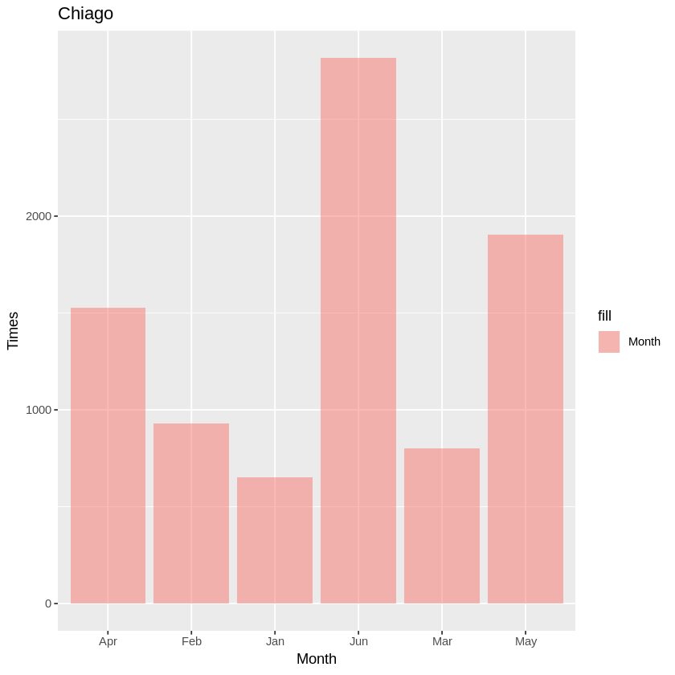

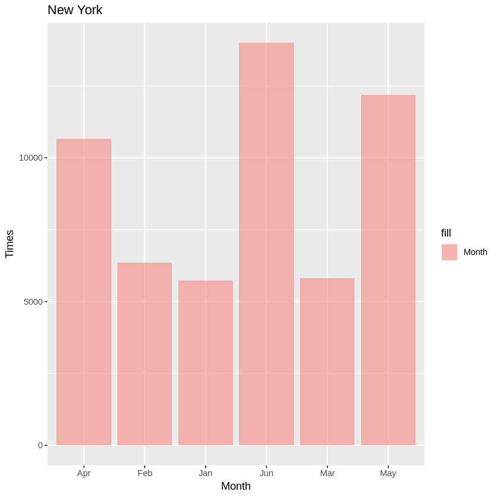

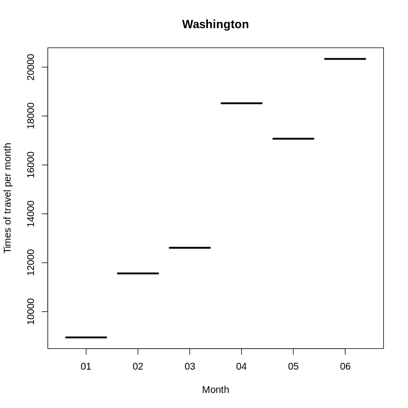

```r
library(dplyr)
library(ggplot2)
library(lubridate)
chi<-chi %>%
  dplyr::mutate(year = lubridate::year(Start.Time),
                month = lubridate::month(Start.Time),
                day = lubridate::day(Start.Time))
table(chi$month)

month <- c("Jan", "Feb", "Mar",
           "Apr", "May", "Jun")
Times <- c(650 , 930  ,803 ,1526, 1905 ,2816 )
dt<-data.frame(Month<-month, Times =Times)


library(ggplot2)
ggplot(dt ,aes( Month,Times )) +
  geom_bar(stat="identity",aes(fill = "Month"), data =dt , alpha = 0.5 ) + ggtitle("Chiago")

months<- format(as.POSIXct(ny$Start.Time, "%Y-%m-%d %H:%M:%S", tz = ""), format = "%m")
ny_month<-strftime(ny$Start.Time, format="%m")
table(ny_month)

ny_month <- c("Jan", "Feb", "Mar",
           "Apr", "May", "Jun")
Times <- c( 5745 , 6364 , 5820 ,10661, 12180, 14000  )
dt<-data.frame(Month<-ny_month, Times =Times)
ggplot(dt ,aes( Month,Times )) +
  geom_bar(stat="identity",aes(fill = "Month"), data =dt , alpha = 0.5 ) + ggtitle("New York")

wash<-as.data.frame(wash)
wash_month<- format(as.POSIXct(wash$Start.Time, "%Y-%m-%d %H:%M:%S", tz = ""), format = "%m")
df3<-table(wash_month)
df3<-as.data.frame(df3)
plot(df3,main="Washington", xlab="Month", ylab="Times of travel per month", pch=18, col="blue")
```

```
weekday_chi
   0    1    2    3    4    5    6
1111 1302 1292 1236 1254 1285 1150
```

```
weekday_wash
    0     1     2     3     4     5     6
11566 11721 13288 14212 13204 12926 12133
```

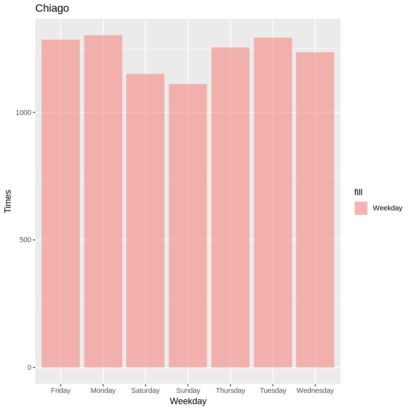

```
weekday_ny
   0    1    2    3    4    5    6
6597 7570 7898 9632 8729 8168 6176
```

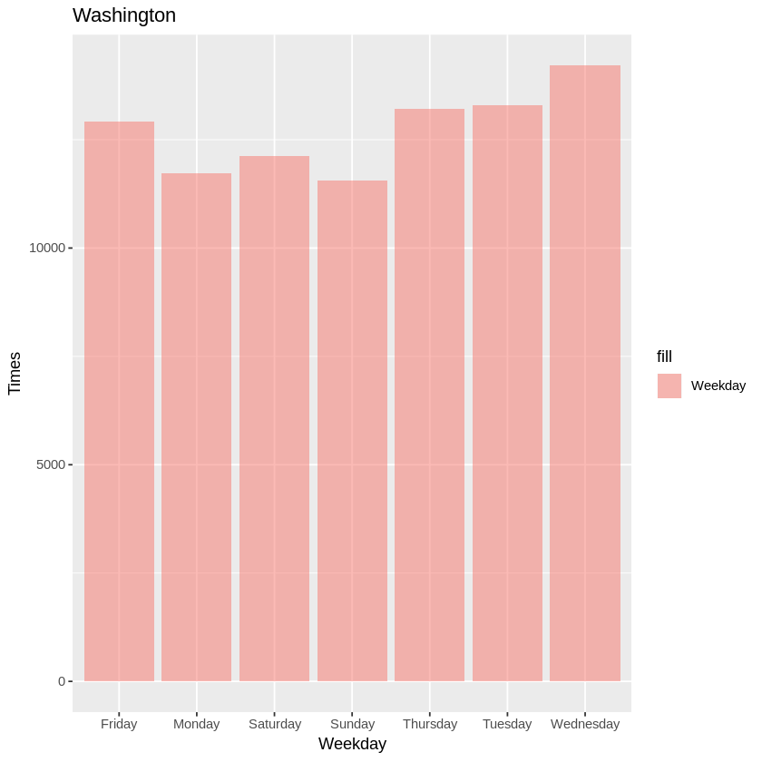

[figure not shown]

```r
library(dplyr)
library(ggplot2)
weekday_chi<-as.POSIXlt(chi$Start.Time)$wday
table(weekday_chi)

Weekday <- c("Sunday", "Monday", "Tuesday",
           "Wednesday", "Thursday", "Friday","Saturday")
Times <- c(1111, 1302, 1292, 1236, 1254 ,1285 ,1150 )
dt1<-data.frame(Weekday<-Weekday, Times =Times)
ggplot(dt1 ,aes( Weekday,Times )) +
  geom_bar(stat="identity",aes(fill = "Weekday"), data =dt1 , alpha = 0.5 ) + ggtitle("Chiago")

wash<-as.data.frame(wash)
wash_weekday<- format(as.POSIXct(wash$Start.Time, "%Y-%m-%d %H:%M:%S", tz = ""))
weekday_wash<-as.POSIXlt(wash_weekday)$wday
table(weekday_wash)

Weekday <- c("Sunday", "Monday", "Tuesday",
           "Wednesday", "Thursday", "Friday","Saturday")
Times <- c(11566 ,11721, 13288 ,14212, 13204, 12926 ,12133  )
dt2<-data.frame(Weekday<-Weekday, Times =Times)
ggplot(dt2 ,aes( Weekday,Times )) +
  geom_bar(stat="identity",aes(fill = "Weekday"), data =dt2 , alpha = 0.5 ) + ggtitle("Washington")

weekday_ny<-as.POSIXlt(ny$Start.Time)$wday
table(weekday_ny)

Weekday <- c("Sunday", "Monday", "Tuesday",
           "Wednesday", "Thursday", "Friday","Saturday")
Times <- c(6597, 7570, 7898, 9632, 8729 ,8168 ,6176  )
dt3<-data.frame(Weekday<-Weekday, Times =Times)
ggplot(dt3 ,aes( Weekday,Times )) +
  geom_bar(stat="identity",aes(fill = "Weekday"), data =dt2 , alpha = 0.5 ) + ggtitle("New York")
```

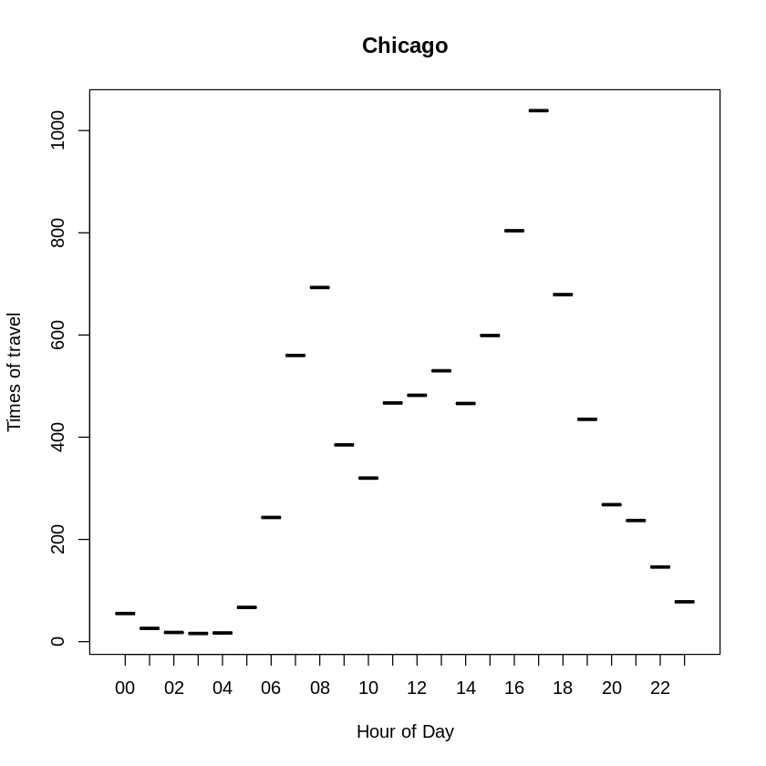

```
ny_hour
  00   01   02   03   04   05   06   07   08   09   10   11   12   13   14   15
 436  231  152   60   84  312 1212 2512 4337 3521 2471 2643 2866 3054 3157 3356
  16   17   18   19   20   21   22   23
3894 5503 5281 3594 2437 1646 1214  797
```

[figure not shown]

[figure not shown]

```r
Hours <- format(as.POSIXct(chi$Start.Time, "%Y-%m-%d %H:%M:%S", tz = ""), format = "%H")
chi_hour<-strftime(chi$Start.Time, format="%H")
df1<-table(chi_hour)
df1<-as.data.frame(df1)
plot(df1,main="Chicago", xlab="Hour of Day", ylab="Times of travel", pch=18, col="blue")


wash<-as.data.frame(wash)
wash_hour <- format(as.POSIXct(wash$Start.Time, "%Y-%m-%d %H:%M:%S", tz = ""))
wash_hour<-strftime(wash_hour, format="%H")
df2<-table(wash_hour)
df2<-as.data.frame(df2)
plot(df1,main="Washington", xlab="Hour of Day", ylab="Times of travel", pch=18, col="blue")


ny<-as.data.frame(ny)
ny_hour <- format(as.POSIXct(ny$Start.Time, "%Y-%m-%d %H:%M:%S", tz = ""))
ny_hour<-strftime(ny_hour, format="%H")
table(ny_hour)
df3<-as.data.frame(df3)
plot(df1,main="New york", xlab="Hour of Day", ylab="Times of travel", pch=18, col="blue")
```

### Question 2

```r
df1<-summary(chi$Start.Station)
df2<-summary(wash$Start.Station)
df3<-summary(ny$Start.Station)

head(df1,1)
head(df2,1)
head(df3,1)
```

**Streeter Dr & Grand Ave:** 210

**Columbus Circle / Union Station:** 1700

**Pershing Square North:** 592

```r
df1<-summary(chi$End.Station)
df2<-summary(wash$End.Station)
df3<-summary(ny$End.Station)

head(df1,1)
head(df2,1)
head(df3,1)
```

**Streeter Dr & Grand Ave:** 233

**Columbus Circle / Union Station:** 1767

**Pershing Square North:** 556

```r
chi$commontrip <- paste(chi$Start.Station,chi$End.Station)
rank_commontrip <- arrange(chi, desc(commontrip)) %>%
          mutate(rank = 1:nrow(chi))
head(rank_commontrip,1)


wash$commontrip <- paste(wash$Start.Station,wash$End.Station)
wash_commontrip <- arrange(wash, desc(commontrip)) %>%
          mutate(rank = 1:nrow(wash))
head(wash_commontrip,1)

ny$commontrip <- paste(ny$Start.Station,ny$End.Station)
ny_commontrip <- arrange(ny, desc(commontrip)) %>%
          mutate(rank = 1:nrow(ny))

head(ny_commontrip,1)
```

| X | Start.Time | End.Time | Trip.Duration | Start.Station | End.Station | User.Type | Gender | Birth.Year | year | month | day | commontrip | rank |
| --- | --- | --- | --- | --- | --- | --- | --- | --- | --- | --- | --- | --- | --- |
| 221550 | 2017-02-20 08:15:27 | 2017-02-20 08:28:24 | 777 | Woodlawn Ave & Lake Park Ave | University Ave & 57th St | Subscriber | Male | 1965 | 2017 | 2 | 20 | Woodlawn Ave & Lake Park Ave University Ave & 57th St | 1 |

| X | Start.Time | End.Time | Trip.Duration | Start.Station | End.Station | User.Type | commontrip | rank |
| --- | --- | --- | --- | --- | --- | --- | --- | --- |
| 1253736 | 2017-05-23 03:15:47 | 2017-05-23 03:41:45 | 1557.887 | Yuma St & Tenley Circle NW | Wisconsin Ave & O St NW | Subscriber | Yuma St & Tenley Circle NW Wisconsin Ave & O St NW | 1 |

| X | Start.Time | End.Time | Trip.Duration | Start.Station | End.Station | User.Type | Gender | Birth.Year | commontrip | rank |
| --- | --- | --- | --- | --- | --- | --- | --- | --- | --- | --- |
| 6669378 | 2017-06-28 17:38:58 | 2017-06-28 17:43:33 | 275 | York St & Jay St | York St & Jay St | Subscriber | Male | 1994 | York St & Jay St York St & Jay St | 1 |

### Question 3

```r
sum_chi<-chi %>% mutate(total_traveltime = sum(Trip.Duration))

head(sum_chi,1)
```

| X | Start.Time | End.Time | Trip.Duration | Start.Station | End.Station | User.Type | Gender | Birth.Year | year | month | day | commontrip | total_traveltime |
| --- | --- | --- | --- | --- | --- | --- | --- | --- | --- | --- | --- | --- | --- |
| 1423854 | 2017-06-23 15:09:32 | 2017-06-23 15:14:53 | 321 | Wood St & Hubbard St | Damen Ave & Chicago Ave | Subscriber | Male | 1992 | 2017 | 6 | 23 | Wood St & Hubbard St Damen Ave & Chicago Ave | 8087801 |

```r
mean_chi<-chi %>% mutate(mean_travel = mean(Trip.Duration))

head(mean_chi,1)
```

| X | Start.Time | End.Time | Trip.Duration | Start.Station | End.Station | User.Type | Gender | Birth.Year | year | month | day | commontrip | mean_travel |
| --- | --- | --- | --- | --- | --- | --- | --- | --- | --- | --- | --- | --- | --- |
| 1423854 | 2017-06-23 15:09:32 | 2017-06-23 15:14:53 | 321 | Wood St & Hubbard St | Damen Ave & Chicago Ave | Subscriber | Male | 1992 | 2017 | 6 | 23 | Wood St & Hubbard St Damen Ave & Chicago Ave | 937.1728 |

```r
chi %>% group_by(User.Type)%>% count
wash%>% group_by(User.Type)%>% count
ny %>% group_by(User.Type)%>% count
```

| User.Type | n |
| --- | --- |
|  | 1 |
| Customer | 1746 |
| Subscriber | 6883 |

| User.Type | n |
| --- | --- |
|  | 1 |
| Customer | 23450 |
| Subscriber | 65600 |

| User.Type | n |
| --- | --- |
|  | 119 |
| Customer | 5558 |
| Subscriber | 49093 |

```r
chi %>% group_by(Gender)%>% count
ny %>% group_by(Gender)%>% count
```

| Gender | n |
| --- | --- |
|  | 1748 |
| Female | 1723 |
| Male | 5159 |

| Gender | n |
| --- | --- |
|  | 5410 |
| Female | 12159 |
| Male | 37201 |

```r
summary(chi$Birth.Year)
summary(wash$Birth.Year)
summary(ny$Birth.Year)
```

```
   Min. 1st Qu.  Median    Mean 3rd Qu.    Max.    NA's
   1899    1975    1984    1981    1989    2002    1747
```

```
Length  Class   Mode
     0   NULL   NULL
```

```
   Min. 1st Qu.  Median    Mean 3rd Qu.    Max.    NA's
   1885    1970    1981    1978    1988    2001    5218
```

## Finishing Up

> Congratulations! You have reached the end of the Explore Bikeshare Data Project. You should be very proud of all you have accomplished!

> **Tip**: Once you are satisfied with your work here, check over your report to make sure that it is satisfies all the areas of the [rubric](https://review.udacity.com/#!/rubrics/2508/view).

## Directions to Submit

> Before you submit your project, you need to create a .html or .pdf version of this notebook in the workspace here. To do that, run the code cell below. If it worked correctly, you should get a return code of 0, and you should see the generated .html file in the workspace directory (click on the orange Jupyter icon in the upper left).

> Alternatively, you can download this report as .html via the **File** > **Download as** submenu, and then manually upload it into the workspace directory by clicking on the orange Jupyter icon in the upper left, then using the Upload button.

> Once you've done this, you can submit your project by clicking on the "Submit Project" button in the lower right here. This will create and submit a zip file with this .ipynb doc and the .html or .pdf version you created. Congratulations!

```r
system('python -m nbconvert Explore_bikeshare_data.ipynb')
```